# Investigating ComBat/CovBat for MVPA

Andrew Chen

## Problem

To evaluate the effect of parametric harmonization methods on multivariate pattern analysis (MVPA), several studies (Chen et al. 2020; Fortin et al. 2018) apply ComBat or ComBat extensions to the whole data followed by splitting the data and training a machine learning algorithm. Then, they evaluate the performance of the model in the test set, which has been previously harmonized. This paradigm can provide insight into whether harmonization methods produce datasets that retain the associations of interest; however, it cannot be implemented in practice. For example, if the goal is to predict Alzheimer’s disease for a patient acquired on a known scanner, ComBat and its extensions cannot be directly applied to the patient’s data without already knowing if they have the disease.

Previously, we have implemented ComBat and CovBat while estimating coefficients only in the training set. While this mitigates the issue, it still does not provide a valid means to harmonize data without knowing the associated covariates.

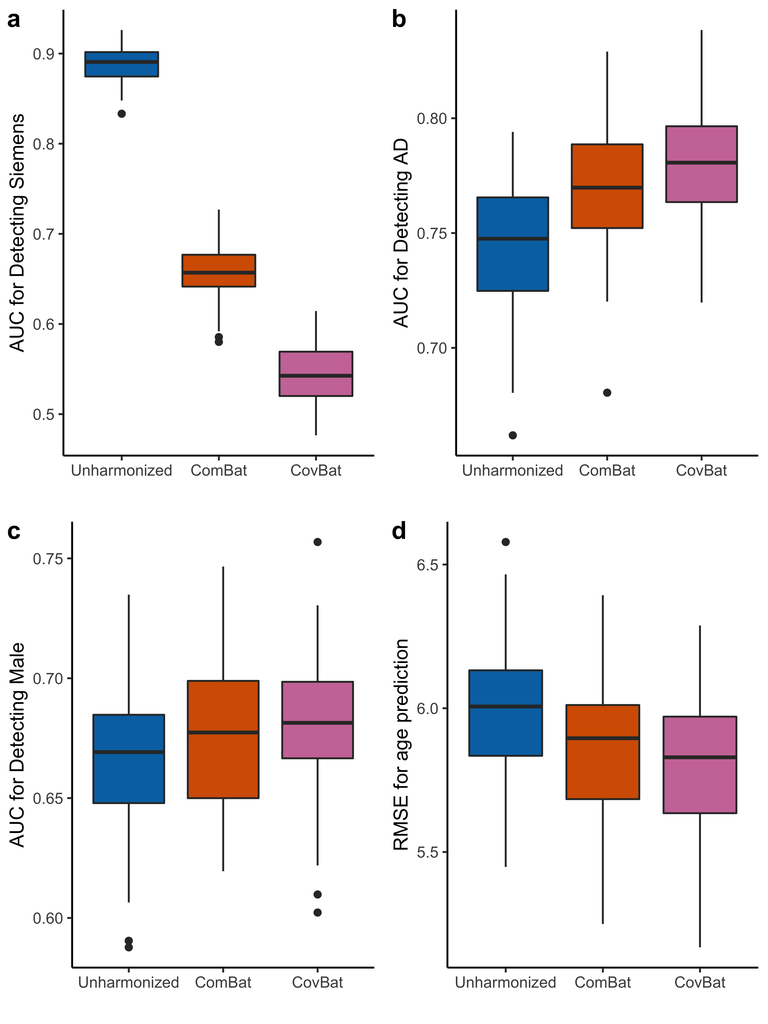

## Potential Solutions

1. Remove scanner effects in test set without regressing out covariates, has a possible risk of removing covariate effect
2. Perform harmonization without the outcome variable in both training and testing
3. Use a propensity score or some kind of surrogate variable to provide a best guess for the covariates based on the test set data
4. Treat the outcome in the machine learning model as missing in the test set and use an imputation method based on other covariates

## Solution 1: Remove scanner effects without residualization

One simple solution is to apply harmonization in the training data then use the estimated scanner mean/variance effects to remove scanner effects from the test set. Performing the latter step without the test labels is not possible using the original ComBat model, but we can instead retain the mean of either the training set or testing set observations.

Denote the training indicies $A = \{(i,j)\mid (i,j)\text{ in training set}\}$ and testing indicies $B = \{(i,j)\mid (i,j)\text{ in testing set}\}$. We assume that the original ComBat model holds for the observations $y_{ijv}$ such that
$$y_{ijv} = \alpha_v + \boldsymbol{x}_{ij}^T \boldsymbol{\beta}_v + \gamma_{iv} + \delta_{iv} e_{ijv}$$
where $e_{ijv} \sim N(0, \sigma_v^2)$. Denote the standardized data $z_{ijv} = \frac{y_{ijv} - \hat{\alpha}_v + \boldsymbol{x}_{ij}^T \hat{\boldsymbol{\beta}_v}}{\hat{\sigma}_{v}}$. Then we obtain our harmonized training set as
$$y_{ijv}^{ComBat} = \frac{\hat{\sigma}_{v}}{\delta_{iv}^*} (z_{ijv} - \gamma_{iv}^*) + \hat{\alpha}_v + \boldsymbol{x}_{ij}^T \hat{\boldsymbol{\beta}}_v$$
for $(i,j) \in A$.

Within the test set $B$, the covariate vectors $\boldsymbol{x}_{ij}$ are unknown. We first choose to remove the mean of each feature within the testing set $\bar{y}_{v}^{\text{test}}$ and use the estimates $\hat{\sigma}_{v}$ from the training data. Our harmonized testing set is then
$$y_{ijv}^{ComBat} = \frac{\hat{\sigma}_{v}}{\delta_{iv}^*} \left(\frac{y_{ijv} - \bar{y}_{v}^{\text{test}}}{\hat{\sigma}_{v}} - \gamma_{iv}^* \right) + \bar{y}_{v}^{\text{test}}$$
for $(i,j) \in B$. For CovBat, we propose a similar method for the test set where we remove site effects from the principal components of $y_{ijv}^{ComBat} - \bar{y}_{v}^{\text{test}}$.

### Evaluation

We evaluate the performance of these proposed methods through a similar MVPA experiment as in the CovBat paper. That is we i) split the sample into 270 training subjects and 235 testing subjects such that both the train and test sets contain at least one subject acquired on each scanner, ii) train a random forests algorithm in the harmonized train set, and iii) assess predictive performance in the test set.

#### Retaining the mean of the testing set

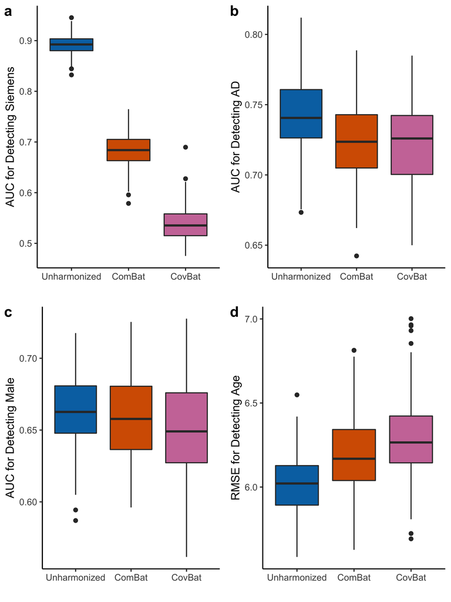

#### Retaining the mean of the training set

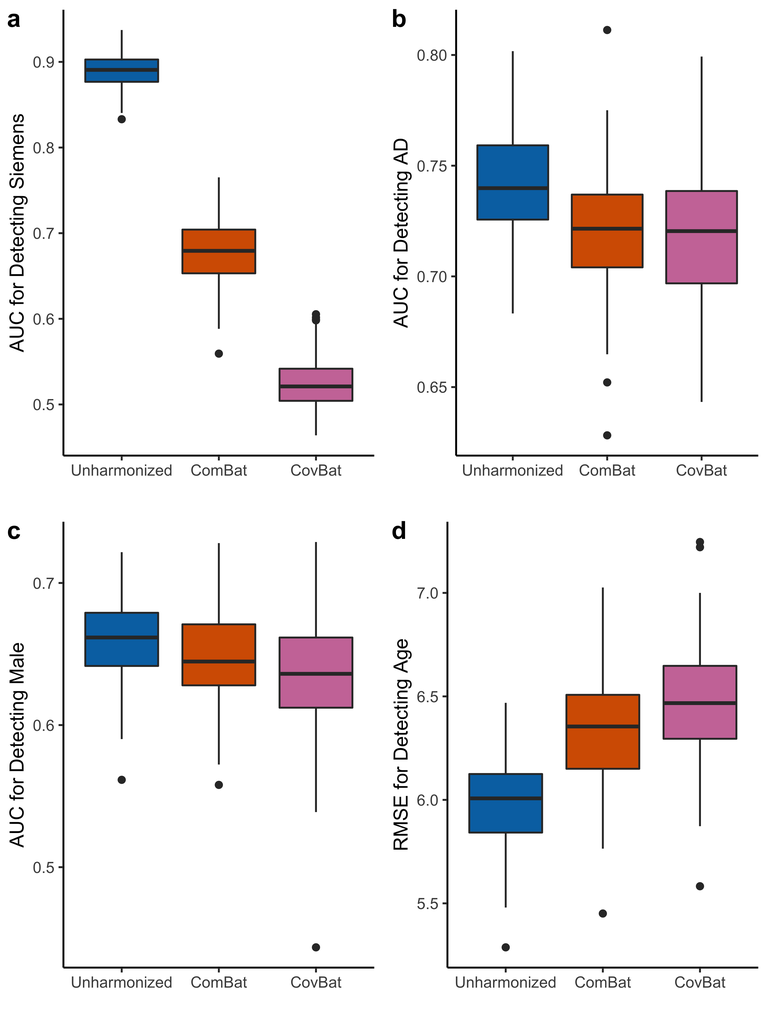

## Solution 2: Remove outcome variable from harmonization

Another idea is to perform harmonization without the outcome variable and use the training set estimates to standardize the testing set observations. This method carries a high risk of removing variation from the data related to the outcome. The results below show that this method indeed seems to lower detection of the outcome.

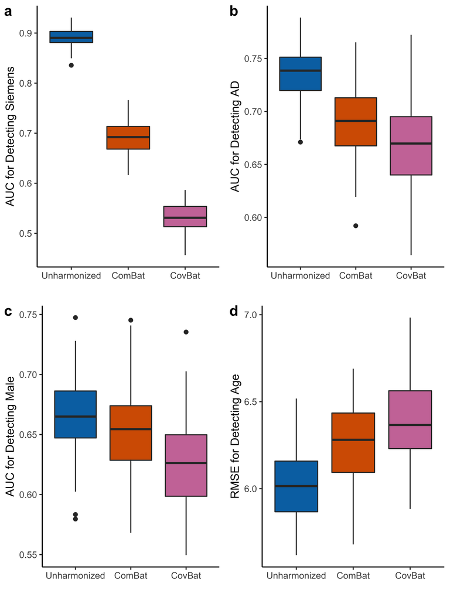

## References

Chen, Andrew A., Joanne C. Beer, Nicholas J. Tustison, Philip A. Cook, Russell T. Shinohara, Haochang Shou, and the Alzheimer’s Disease Neuroimaging Initiative. 2020. “Removal of Scanner Effects in Covariance Improves Multivariate Pattern Analysis in Neuroimaging Data.” *bioRxiv*, June. Cold Spring Harbor Laboratory, 858415. https://doi.org/10.1101/858415.

Fortin, Jean-Philippe, Nicholas Cullen, Yvette I. Sheline, Warren D. Taylor, Irem Aselcioglu, Philip A. Cook, Phil Adams, et al. 2018. “Harmonization of Cortical Thickness Measurements Across Scanners and Sites.” *NeuroImage* 167 (February): 104–20. https://doi.org/10.1016/j.neuroimage.2017.11.024.